# ES sites in Pakistan - 2021-24

# Background

Confidence in the interruption of poliovirus transmission is highly dependent on assumed sensitivity of environmental surveillance (ES), in particular in the case of cVDPV2 (low rate of clinical disease). Previous work has explored how the strength of evidence against ongoing circulation is influenced by variation in which sites (in which locations, relative to the distribution of population) are reporting samples at what time. This work also incorporated detection rate of NPEVs as another source of variation between sites, hence variation in the strength of evidence for absence in that location when no poliovirus has been detected.

The latter indicator was considered only with respect to a fixed target rate defined by the GPEI (>50%), which is used to monitor site performance and inform their opening/closure. This means that sites detecting NPEVs in an average of 50% of collected samples over the previous 12 months are considered as performing at their “maximum”, with our measurement of sensitivity scaled down when this value falls below 50%. In fact, the 50% threshold is arbitrarily defined and doesn’t necessarily align with the expected prevalence of NPEVs in the population, in different locations and at different times of year.

In this setting, the nature of collection sites varies considerably between natural waterways, informal drainage channels, and more formal sewage networks. These different types of site will likely have very different population catchment and virus detection sensitivity. Sites are, however, only defined by name and GPS location. In order to distinguish different site types, we can look at the land cover surrounding the site and the proximity/intersection with natural water bodies.

Ultimately, we want to infer the relationship between probability of NPEV detection and: - Population size within Xkm - Dominant land cover type within Xkm - Proximity to natural waterways/bodies - Elevation within Xkm compared to elevation at site? [- Proportion of “flooded vegetation” within Xkm]

For the last point, we are interested in the influence of seasonal flooding on NPEV detection. This may alter the usual catchment of a site, as well as diluting/contaminating samples with run-off from other regions. However, this is not a significant consideration in the context of Nigeria and should instead be explored in a more flood-prone setting such as Pakistan.

Methodological approach:

- Fit GAM of P(NPEV) ~ catch_pop + lc_type + proximity_water - Investigate anisotropy in the correlation structure via directional variograms.
- Investigate shift in Pr NPEV detection during July/August 2022, comparing sites within/without flood-affected area.

## Set up environment and load data

```r
pacman::p_load(tidyverse, sf, janitor, terra, exactextractr, mgcv, gstat, broom)
theme_set(theme_minimal())

# Inputs
indir <- "data/Pakistan"
proj_local <- "EPSG:32631"

# ES linelist
es <- readRDS(file.path(indir,"es.rds")) |>
  mutate(nonpolio = is.na(final_class)|final_class %in% c("NPEV","VACCINE"))

# AFP linelist
afp <- readRDS(file.path(indir,"afp.rds"))

# Population raster
poprast  <- rast(file.path(indir,"proj_pop_rast.tif"))

# Administrative boundaries
shape2 <- readRDS(file.path(indir, "shape2.rds")) |>
  st_transform(proj_local)

shape0 <- st_union(shape2)
```

Summarise non-polio AFP cases by district:

```r
afp |>
  filter(is.na(classification) | classification == "Discarded") |>
  pull(classification) |> table()
```

```
Discarded
    74226
```

# Descriptive

## Unique sites and characteristics

```r
es |>
  select(guid, admin_0:admin_2, site_id, site_name, x, y) |>
  unique() -> es_sites

glimpse(es_sites)
```

```
Rows: 639
Columns: 8
$ guid      <chr> "{BCA4E953-DD04-4559-9808-636AAAF43E34}", "{E89BB733-608B-409E-9F4D-1A0E81BE832B}", "{7FC1E5DD-206F-46CC-…
$ admin_0   <chr> "PAKISTAN", "PAKISTAN", "PAKISTAN", "PAKISTAN", "PAKISTAN", "PAKISTAN", "PAKISTAN", "PAKISTAN", "PAKISTAN…
$ admin_1   <chr> "SINDH", "SINDH", "SINDH", "SINDH", "SINDH", "SINDH", "SINDH", "SINDH", "SINDH", "PUNJAB", "PUNJAB", "PUN…
$ admin_2   <chr> "TMKHAN", "MATIARI", "KHAIRPUR", "UMERKOT", "T.ALLAHYAR", "NFEROZ", "THATTA", "THARPARKAR", "MATIARI", "L…
$ site_id   <chr> "PAK/SD/TMK/SP-1", "PAK/SD/MAT/LP-1", "PAK/SD/KHP/KS-1", "PAK/SD/UMR/GW-1", "PAK/SD/TAY/TA-1", "PAK/SD/NS…
$ site_name <chr> "SONPARI PUMPING STATION", "LATIF COLONY PUMPING STATION BHITSHAH", "KHAKHI SHAH PULL PUMPING STATION", "…
$ x         <dbl> 68.41182, 68.49029, 69.06469, 69.78273, 68.76135, 67.85753, 67.35842, 70.76702, 68.31948, 74.36128, 74.39…
$ y         <dbl> 25.14902, 25.81112, 26.98466, 25.44345, 25.62664, 26.59874, 24.22578, 24.36207, 26.03133, 31.54671, 31.33…
```

In total, 639 unique sites active at some point between 2021-01-01 and 2024-12-24.

Check uniqueness of coordinates per site code:

```r
nrow(es_sites)
```

```
[1] 639
```

```r
n_distinct(es_sites$site_id)
```

```
[1] 639
```

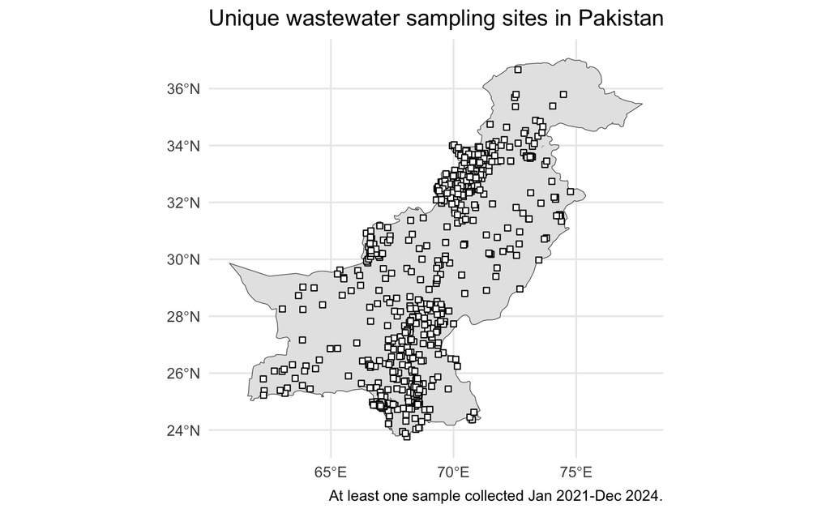

```r
ggplot() +
  geom_sf(data = shape0 |> st_transform(4326)) +
  geom_sf(data = st_as_sf(es_sites, coords = c("x","y"), crs = 4326),
          pch = 22, fill = "white") +
  labs(title = "Unique wastewater sampling sites in Pakistan",
       caption = "At least one sample collected Jan 2021-Dec 2024.")
```

### Site names

Can we glean anything from site names? - Some in particular refer to bridges, specific streams/rivers, community hubs (e.g. school/mosque/camp/police station) and road intersections (junction/roundabout) - There is one formal wastewater treatment plant

What proportion of samples from identifiable site types are NPEV-positive?

```r
es_sites |>
  mutate(keywords = gsub("[ ]", "", site_name)) |> separate_rows(keywords, sep = " ") |>
  group_by(keywords) |>
  summarise(count = n()) |>
  arrange(desc(count))
```

| keywords | count |
| --- | --- |
| ABDULKHALIQROAD | 1 |
| ADALATROAD | 1 |
| ADDAKHEILBAZAR | 1 |
| ADMOREPUMPBYPASSGAMBAT | 1 |
| AFGHANREFUGEECAMPZALAI | 1 |
| AINPOSH | 1 |
| AIRPORTMOHALLAH | 1 |
| AKBARJANMOHALLAHUCBADAMA | 1 |
| ALHAFIZPETROLPUMPNALA | 1 |
| ALLAHYARTURKVILLAGEDRAIN | 1 |

[output cut: 629 more lines]

```r
NA
```

```r
es |>
  mutate(site_name = tolower(site_name),
         drain = grepl("drain",site_name) | grepl("sewage",site_name) |
           grepl("disposal",site_name) | grepl("sewer",site_name) ,
         water = grepl("stream",site_name) | grepl("river",site_name) |
           grepl("pond",site_name) | grepl("canal",site_name),
         comm_site = grepl("school",site_name) | grepl("college",site_name) |
           grepl("market",site_name) | grepl("masjid",site_name),
         hosp = grepl("hospital", site_name),
         junction = grepl("junction",site_name),
         wwtp = (grepl("pumping",site_name)|
                   (grepl("pump", site_name) & grepl("station", site_name))|
                   grepl("plant", site_name)),
         no_type = !(drain|water|comm_site|hosp|junction|wwtp)) -> tmp

tmp |> summarise(across(drain:no_type, sum))
```

| drain | water | comm_site | hosp | junction | wwtp | no_type |
| --- | --- | --- | --- | --- | --- | --- |
| 448 | 4 | 78 | 83 | 0 | 645 | 4766 |

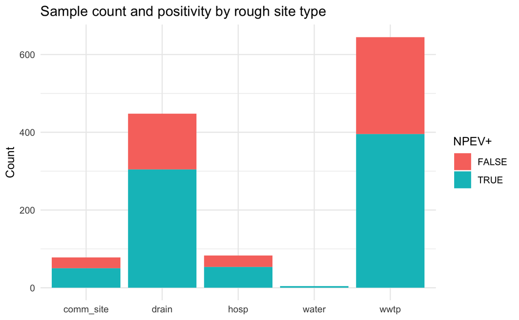

```r
tmp |>
  pivot_longer(drain:no_type, names_to = "type") |>
  filter(value, type != "no_type") |>
  ggplot(aes(type, fill = !is.na(npev))) +
  geom_bar() +
  labs(fill = "NPEV+", x = NULL, y = "Count", title = "Sample count and positivity by rough site type")
```

Not really helpful…

Just distinguish WWTPs:

```r
es_sites |>
  full_join(select(tmp, site_id, wwtp) |> distinct()) -> es_sites
tabyl(es_sites$wwtp)
```

```
 es_sites$wwtp   n   percent
         FALSE 553 0.8654147
          TRUE  86 0.1345853
```

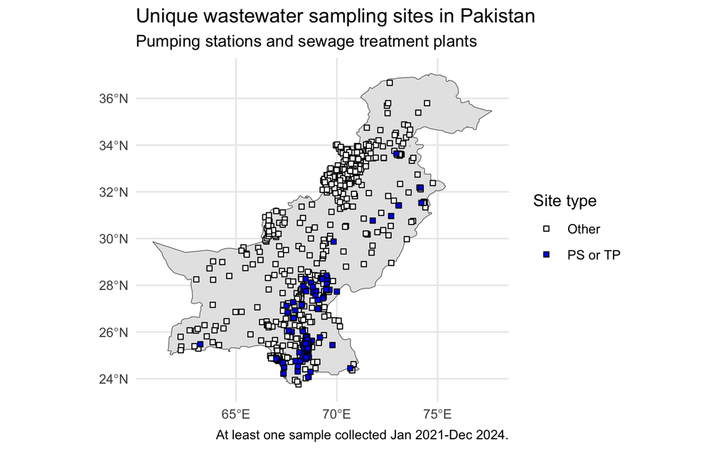

```r
es_sites <- es_sites |>
  mutate(wwtp_f = factor(wwtp, levels = c(FALSE,TRUE), labels = c("Other","PS or TP"))) |>
  arrange(wwtp_f)

ggplot() +
  geom_sf(data = shape0 |> st_transform(4326)) +
  geom_sf(data =  st_as_sf(es_sites, coords = c("x","y"), crs = 4326),
          aes(fill = wwtp_f),
          pch = 22) +
  scale_fill_manual("Site type",values = c("white","blue1")) +
  labs(title = "Unique wastewater sampling sites in Pakistan",
       subtitle = "Pumping stations and sewage treatment plants",
       caption = "At least one sample collected Jan 2021-Dec 2024.")
```

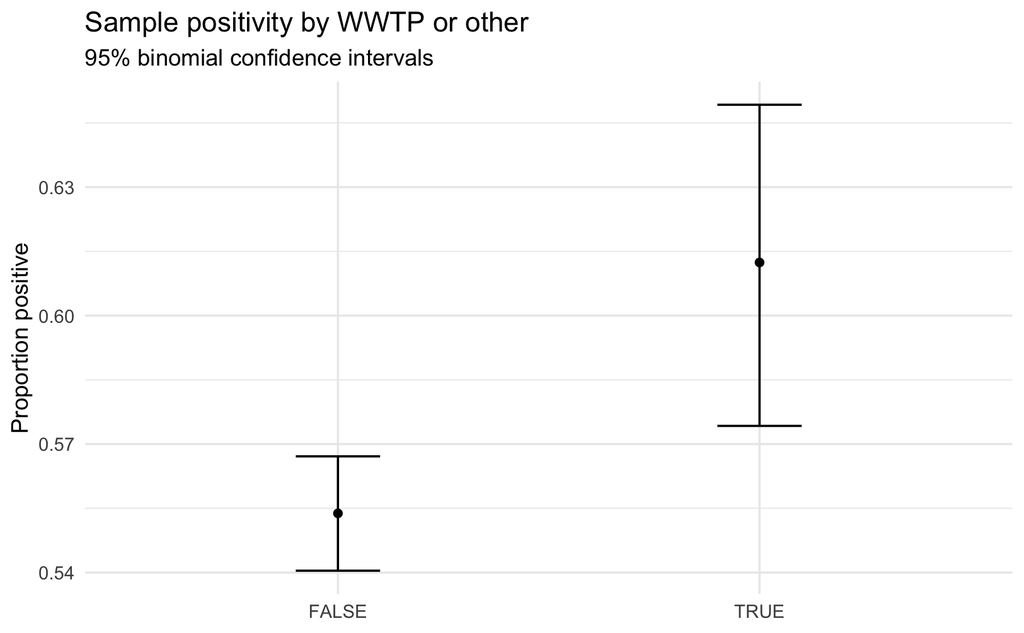

```r
tmp |>
  group_by(wwtp) |>
  summarise(n = n(),
            npev_pos = sum(!is.na(npev)),
            lo = Hmisc::binconf(npev_pos, n)[2],
            hi = Hmisc::binconf(npev_pos, n)[3]) |>
  ungroup() |>
  ggplot(aes(wwtp, npev_pos/n, ymin = lo, ymax = hi)) +
  geom_errorbar(width = 0.2) +
  geom_point() +
  # ylim(c(0.5,1)) +
  labs(fill = "NPEV+",
       x = NULL, y = "Proportion positive",
       title = "Sample positivity by WWTP or other",
       subtitle = "95% binomial confidence intervals")
```

### Catchment population

```r
es_sites_utm <- st_as_sf(es_sites, coords = c("x","y"), crs = 4326) |>
  st_transform(proj_local)

es_buff <- st_buffer(es_sites_utm, dist = units::set_units(2, "km"))

# Population within 2km of each site:
es_sites_utm$catchment_2k <- exactextractr::exact_extract(poprast, es_buff, "sum")

# Total population per admin2 area:
shape2$total_pop <- exactextractr::exact_extract(poprast, shape2, "sum")

hist(es_sites_utm$catchment_2k)
summary(es_sites_utm$catchment_2k)
```

On average, 1.318053^{4} people reside within 2km of an individual collection site, with a total of 7.3810967^{6} within 2km of *any* site (~3% of the national population).

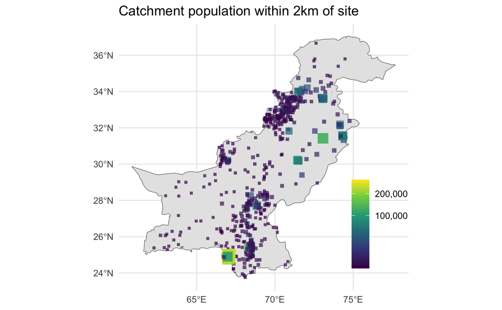

```r
ggplot() +
  geom_sf(data = shape0 |> st_transform(4326)) +
  geom_sf(data = es_sites_utm |> st_transform(4326), aes(size = catchment_2k, colour = catchment_2k), pch = 15, alpha = 0.7) +
  scale_colour_viridis_c(trans = "sqrt", labels = scales::label_comma()) +
  theme(legend.position = c(0.9,0.25)) +
  guides(size = "none") +
  labs(colour = NULL,
       title = "Catchment population within 2km of site")
```

### Sample frequency

How many samples are collected per site?

```r
es |>
  mutate(collection_month = month,
         month = lubridate::month(month, label = T)) |>
  group_by(collection_month, month, year, site_id, x, y) |>
  summarise(
    n_samples = n(),
    n_cvdpv2 = sum(final_class == "cVDPV2", na.rm = T),
    n_npev = sum(!is.na(npev))) |>
  ungroup() -> es_mth
tabyl(es_mth, n_samples)
```

```
 n_samples    n     percent
         1 1905 0.959214502
         2   78 0.039274924
         3    3 0.001510574
```

```r
tabyl(es_mth, month, n_samples)
```

```
 month   1  2 3
   Jan  81  5 0
   Feb  72  3 0
   Mar  99  2 0
   Apr 170  8 0
   May 224 11 0
   Jun 155  5 0
   Jul 305 12 1
   Aug 340 11 2
   Sep 174 13 0
   Oct 127  3 0
   Nov  85  3 0
   Dec  73  2 0
```

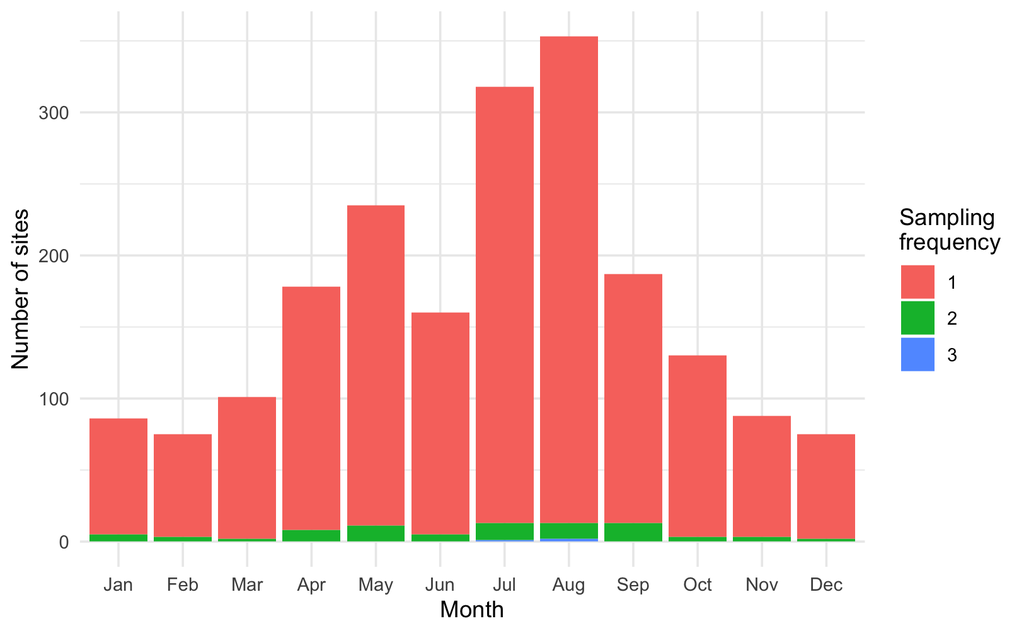

```r
ggplot(st_drop_geometry(es_mth)) +
  geom_bar(aes(month, fill = as.factor(n_samples))) +
  labs(y = "Number of sites", x = "Month", fill = "Sampling\nfrequency")
```

The majority of sites are reporting one sample per month, with the rest reporting two. On very few occasions has a site reported more than two samples in a given month. Which sites are these? Do some consistently report more than others?

```r
es_mth |>
  filter(n_samples > 2) |>
  st_as_sf(coords = c("x","y"), crs = 4326) |>
  st_jitter() |>
  ggplot() +
  geom_sf(data = shape0 |> st_transform(4326)) +
  geom_sf(pch = "+", cex = 5, alpha = 0.5) +
  theme_void()
```

### Sample quality

Reported sample quality likely links to the sensitivity for NPEV detection, however few samples are reported as something other than “good”:

```r
tabyl(es$sample_condition)
ggplot(es, aes(year, fill = sample_condition)) +
  geom_bar()

es |>
  group_by(site_id, x, y) |>
  summarise(p_qual = mean(!is.na(sample_condition) & sample_condition == "Good")) |>
  ungroup() |>
  st_as_sf(coords = c("x","y"), crs = 4326) -> tmp
ggplot() +
  geom_sf(data = shape0 |> st_transform(4326)) +
  geom_sf(data = tmp, aes(fill = p_qual), pch = 22) +
  scale_fill_viridis_c(limits = c(0,1)) +
  theme(legend.position = c(0.9,0.25)) +
  labs(fill = NULL,
       title = "Overall proportion of good-condition samples",
       caption = "At least one sample collected Jan 2021-Dec 2024.")
```

### Land cover within catchment area

If we can’t really distinguish site types from their name, perhaps we can infer something from the type environment surrounding the site location, e.g. - Urbanicity - Land cover - Proximity to water

Load rasters of land use and distance to waterways: [Note that these from WorldPop are quite out of date - should be replaced with ESRI land cover estimates]

```r
# water_dist  <- rast("data/nga_osm_dst_waterway_100m_2016.tif") |>
#   terra::project(proj_local)
#
# built_extent  <- rast("data/nga_bsgme_v0a_100m_2020.tif") |>
#   terra::project(proj_local)
```

```r
#
# plot(water_dist)
# plot(built_extent)
```

- Built extent raster is binary, but seems to be aggregated to a different resolution in autoplot hence non-binary values.
- Water distance raster is in km to the nearest *major* waterway.

First look at the point value at each site (create a small buffer to still use exact_extract):

```r
# es_buff_sm <- st_buffer(es_sites_utm, dist = units::set_units(50, "m"))
#
# es_sites_utm$built_extent <- exactextractr::exact_extract(built_extent, es_buff_sm, "mean")
# es_sites_utm$water_dist <- exactextractr::exact_extract(water_dist, es_buff_sm, "mean")
#
# summary(es_sites_utm$built_extent)
# hist(es_sites_utm$built_extent)
#
# summary(es_sites_utm$water_dist)
# hist(es_sites_utm$water_dist)
```

Also look at average value within 2km catchment:

```r
# es_sites_utm$built_2k <- exactextractr::exact_extract(built_extent,
#                                                       es_buff,
#                                                       "mean")
# es_sites_utm$water_2k <- exactextractr::exact_extract(water_dist,
#                                                       es_buff,
#                                                       "mean")
#
# ggplot(es_sites_utm, aes(built_extent, built_2k)) + geom_abline() + geom_point(alpha = 0.5)
# ggplot(es_sites_utm, aes(water_dist, water_2k)) + geom_abline() + geom_point(alpha = 0.5)
```

Makes sense that water distance is essentially equal - we’ve just added 2km radius and many values are tens of km away.

## NPEV detection by site and month

### Overall

```r
es |>
  ggplot(aes(year, fill = !is.na(npev))) +
  geom_bar() +
  labs(x = NULL, y = "No. Samples", fill = "NPEV+")

es |>
  group_by(year) |>
  summarise(n = n(),
            npev_pos = sum(!is.na(npev)),
            lo = Hmisc::binconf(npev_pos, n)[2],
            hi = Hmisc::binconf(npev_pos, n)[3]) |>
  ungroup() |>
  ggplot(aes(year, npev_pos/n, ymin = lo, ymax = hi)) +
  geom_errorbar(width = 0.2) +
  geom_point() +
  ylim(c(0,1)) +
  labs(fill = "NPEV+",
       x = NULL, y = "Proportion positive",
       title = "Sample NPEV positivity by year",
       subtitle = "95% binomial confidence intervals")

es |>
  group_by(month) |>
  summarise(n = n(),
            npev_pos = sum(!is.na(npev)),
            lo = Hmisc::binconf(npev_pos, n)[2],
            hi = Hmisc::binconf(npev_pos, n)[3]) |>
  ungroup() |>
  ggplot(aes(month, npev_pos/n, ymin = lo, ymax = hi, col = (npev_pos/n > 0.5))) +
  geom_errorbar(width = 0.2) +
  geom_point() +
  geom_vline(xintercept = ymd(paste0(2021:2025,"-01-01")),
             lty = "dashed", col = "grey") +
  ylim(c(0,1)) +
  labs(fill = "NPEV+",
       x = NULL, y = "Proportion positive",
       col = "NPEV+ > 50%",
       title = "Sample NPEV positivity by month",
       subtitle = "95% binomial confidence intervals")


es |>
  mutate(site_no = as.numeric(as.factor(site_id))) |>
  group_by(admin_1, site_id, site_no) |>
  summarise(n = n(),
            npev_pos = sum(!is.na(npev)),
            lo = Hmisc::binconf(npev_pos, n)[2],
            hi = Hmisc::binconf(npev_pos, n)[3]) |>
  group_by(admin_1) |>
  mutate(adm1_br = ifelse(row_number() == 1, site_no - 0.5, NA)) |>
  ungroup() |>
  ggplot(aes(site_no, npev_pos/n, ymin = lo, ymax = hi, col = (npev_pos/n > 0.5))) +
  geom_errorbar(width = 0.2) +
  geom_point() +
  geom_vline(aes(xintercept = adm1_br)) +
  ylim(c(0,1)) +
  labs(fill = "NPEV+",
       x = NULL, y = "Proportion positive",
       col = "NPEV+ > 50%",
       title = "Sample NPEV positivity by site",
       subtitle = "95% binomial confidence intervals")
```

```r
es |>
  group_by(site_id, x, y) |>
  summarise(p_npev = sum(!is.na(npev))/n(),
            pop = mean(catchment_pop_5k)) |>
  ungroup() |>
  st_as_sf(coords = c("x","y"), crs = 4326) -> tmp
ggplot() +
  geom_sf(data = shape0 |> st_transform(4326)) +
  geom_sf(data = tmp, aes(col = p_npev*100, size = pop), pch = 15, alpha = 0.6) +
  scale_colour_viridis_c(limits = c(0,100)) +
  # theme(legend.position = c(0.9,0.25)) +
  labs(fill = NULL,
       colour = "% NPEV+",
       size = "Estimated\ncatchment",
       title = "Percentage of NPEV+ samples per site",
       caption = "At least one sample collected Jan 2021-Dec 2024.") +
  theme_void()
```

### By time

```r
es |>
  ggplot(aes(month, fill = !is.na(npev))) +
  geom_bar() +
  labs(x = "Collection month", y = "No. samples", fill = "NPEV+")

es |>
  mutate(collection_month = month,
         month = lubridate::month(collection_month, label = T)) |>
  group_by(site_id, x, y, year, month, collection_month) |>
  summarise(n_samples = n(),
            p_npev = sum(!is.na(npev))/n_samples) |>
  ungroup() |>
  st_as_sf(coords = c("x","y"), crs = 4326) -> tmp

tmp |>
  mutate(year = as.factor(year)) |>
  ggplot(aes(month, p_npev, group = year)) +
  geom_line(alpha = 0.5, col = "grey") +
  geom_smooth(aes(col = year), method = "loess") +
  labs(x = NULL, y = "Prop. NPEV+", col = "Year")
```

### By site and time

```r
es |>
  group_by(site_id, x, y, year) |>
  summarise(n_samples = n(),
            p_npev = sum(!is.na(npev))/n_samples) |>
  ungroup() |>
  st_as_sf(coords = c("x","y"), crs = 4326) -> tmp

ggplot() +
  geom_sf(data = shape0 |> st_transform(4326), fill = "white") +
  geom_sf(data = st_jitter(tmp, factor = 0.0005),
          aes(col = p_npev, alpha = n_samples)) +
  facet_wrap(~year) +
  scale_color_viridis_c(trans = "sqrt", direction = 1) +
  labs(caption = "Points jittered for visibility.",
       title = "NPEV positivity per site, per year",
       alpha = "No. samples",
       colour = "Proportion") +
  theme_bw() +
  theme(axis.text = element_blank(), axis.ticks = element_blank())

ggplot() +
  geom_sf(data = shape0 |> st_transform(4326)) +
  geom_sf(data = st_jitter(tmp, factor = 0.0005), aes(fill = (p_npev >= 0.5)), pch = 22) +
  facet_wrap(~year) +
  theme_minimal() +
  labs(caption = "Points jittered for visibility.",
       fill = NULL,
       title = "At least 50% NPEV positivity") +
  theme_bw() +
  theme(axis.text = element_blank(), axis.ticks = element_blank())
```

# Modelling

## Make analysis dataset

To begin with, look at just total per year given site characteristics and location.

Aggregate samples to site/month/year totals and define spatial geometry:

```r
es |>
  mutate(collection_month = month,
         month = lubridate::month(month, label = T)) |>
  group_by(collection_month, month, year, site_id, x, y) |>
  summarise(
    n_samples = n(),
    n_cvdpv2 = sum(final_class == "cVDPV2", na.rm = T),
    n_npev = sum(!is.na(npev))) |>
  ungroup()|>
  mutate(p_npev = n_npev/n_samples,
         p_cvdpv2 = n_cvdpv2/n_samples) |>
  left_join(es_sites_utm |> st_drop_geometry() |> select(site_id, catchment_2k)) -> es_agg_mth

es_pt_mth <- es_agg_mth |>
  st_as_sf(coords = c("x","y"), crs = 4326)

es_pt_mth |>
  group_by(year, site_id, catchment_2k) |>
  summarise(across(n_samples:n_npev, sum)) |>
  ungroup()|>
  mutate(p_npev = n_npev/n_samples,
         p_cvdpv2 = n_cvdpv2/n_samples) -> es_pt_yr
```

```r
ggplot() +
  geom_sf(data = shape0 |> st_transform(4326)) +
  geom_sf(data = st_jitter(es_pt_yr, factor = 0.0005), pch = 22, fill = "white") +
  facet_wrap(~year) +
  theme_minimal() +
  labs(caption = "Points jittered for visibility.",
       title = "Unique sites reporting samples between Jan 2021 and Oct 2024")

ggplot() +
  geom_sf(data = shape0 |> st_transform(4326)) +
  geom_sf(data = st_jitter(es_pt_yr, factor = 0.0005), aes(col = p_npev), cex = 0.8) +
  facet_wrap(~year) +
  scale_color_viridis_c(trans = "sqrt") +
  theme_minimal() +
  labs(caption = "Points jittered for visibility.",
       title = "NPEV positivity per site, per year",
       colour = "Proportion")

ggplot() +
  geom_sf(data = shape0 |> st_transform(4326)) +
  geom_sf(data = st_jitter(es_pt_yr, factor = 0.0005), aes(fill = (p_npev >= 0.5)), pch = 22) +
  facet_wrap(~year) +
  theme_minimal() +
  labs(caption = "Points jittered for visibility.",
       fill = NULL,
       title = "At least 50% NPEV positivity")
```

Initially few sites with >50% NPEV positivity rate per year, but increasing over time.

Visualise these predictors against empirical logit of p[NPEV]:

```r
es_pt_yr |>
  mutate(elogitp = log((n_npev+0.5)/(n_samples-n_npev+0.5))) |>
  bind_cols(st_coordinates(es_pt_yr)) |>
  st_drop_geometry() |>
  select(catchment_2k, year,
         X, Y,
         elogitp) %>%
  pivot_longer(-elogitp) %>%
  ggplot(aes(value, elogitp)) +
  geom_jitter(alpha = 0.5) +
  geom_smooth() +
  facet_wrap(~name, scales = "free_x") +
  theme_bw()
```

Also for monthly positivity:

```r
es_pt_mth |>
  mutate(elogitp = log((n_npev+0.5)/(n_samples-n_npev+0.5)),
         month = as.numeric(month)) |>
  bind_cols(st_coordinates(es_pt_mth)) |>
  st_drop_geometry() |>
  select(month, year,
         catchment_2k,
         X, Y,
         elogitp) |>
  pivot_longer(-elogitp) |>
  ggplot(aes(value, elogitp)) +
  geom_jitter(alpha = 0.2) +
  geom_smooth() +
  facet_wrap(~name, scales = "free_x") +
  theme_bw()
```

## Monthly

```r
plot_es_npev_pos <- function(yr){
 ggplot() +
  geom_sf(data = shape0 |> st_transform(4326)) +
  geom_sf(data = st_jitter(filter(es_pt_mth, year == yr), factor = 0.0005),
          aes(col = p_npev, size = n_samples), alpha = 0.5) +
  facet_wrap(~month) +
  scale_color_viridis_c(trans = "sqrt") +
  theme_minimal() +
  theme(axis.text = element_blank()) +
  labs(caption = "Points jittered for visibility.",
       title = paste0("NPEV positivity per site, per month (",yr,")"),
       colour = "Proportion\npositive",
       alpha = "No.\nsamples") -> p

  return(p)
}

lapply(c(2021:2024), plot_es_npev_pos)
```

Look at seasonal trend by year:

```r
es_pt_mth |>
  mutate(year = as.factor(year)) |>
  ggplot(aes(month, p_npev, group = year)) +
  geom_line(alpha = 0.5, col = "grey") +
  geom_smooth(aes(col = year), method = "loess")
```

Between 2021-23 there was an overall increase in NPEV positivity, with a similar late-summer peak each year. The increase towards the peak is more gradual than the decrease after. In 2021 and 2023 we see a small bump coming up to July but this is not observed in 2022, which appears more wobbly.

The 2024 trend is quite different to the other years, generally decreasing with a small bump in June.

```r
plot_es_npev_pos <- function(yr){
 ggplot() +
  geom_sf(data = shape0 |> st_transform(4326)) +
  geom_sf(data = st_jitter(filter(es_sf, year == yr), factor = 0.0005),
          aes(col = p_npev, size = n_samples), alpha = 0.5) +
  facet_wrap(~month) +
  scale_color_viridis_c(trans = "sqrt") +
  theme_minimal() +
  theme(axis.text = element_blank()) +
  labs(caption = "Points jittered for visibility.",
       title = paste0("NPEV positivity per site, per month (",yr,")"),
       colour = "Proportion\npositive",
       alpha = "No.\nsamples") -> p

  return(p)
}

lapply(c(2021:2024), plot_es_npev_pos)
```

Try fitting a model by month:

```r
modeldata_m <- bind_cols(es_pt_mth, st_coordinates(es_pt_mth)) |>
  mutate(m = as.numeric(month),
         year_f = as.factor(year)) |>
  group_by(site_id) |>
  mutate(sid = cur_group_id() |>  as.factor()) |>
  ungroup()

m4 <- gam(data = modeldata_m,
          weights = n_samples,
          p_npev ~ s(catchment_2k, k = 3) + # s(built_2k, k = 3) + s(water_dist, k = 3) +
            s(m, by = year_f, k = 5) + year_f +
            s(X, Y, bs = "gp"),
          family = binomial())

summary(m4)
plot(m4, pages = 1)
```

Want to look at effect of recent rainfall on npev detection, and in particular when in time this effect was significant e.g. here[https://r.qcbs.ca/workshop08/book-en/changing-the-basis-function.html] and here[https://aslopubs.onlinelibrary.wiley.com/doi/10.4319/lo.2009.54.6_part_2.2529].

# Incorporate NPEV in AFP notifications

```r
afp |>
  group_by(guid,x,y) |>
  count(name = "n_unique") |>
  ungroup() |>
  group_by(n_unique) |>
  count()

afp |>
  select(guid, x, y) |>
  unique() -> afp_locs

table(afp$npev)
```

```r
ggplot() +
  geom_sf(data = shape0 |> st_transform(4326)) +
  geom_sf(data = st_as_sf(afp_locs, coords = c("x","y"), crs = 4326), pch = 22, fill = "white") +
  labs(title = "Given locations of notified AFP cases",
       caption = "Jan 2021-Dec 2024.")

ggplot() +
  geom_sf(data = shape0 |> st_transform(4326)) +
  geom_sf(data = st_as_sf(afp |> filter(!is.na(npev)), coords = c("x","y"), crs = 4326),
          aes(fill = onset_date), pch = 22, alpha = 0.4) +
  scale_fill_viridis_c() +
  theme(legend.position = c(0.9,0.25)) +
  labs(fill = NULL,
       title = "NPEV-positive notified AFP cases",
       caption = "Jan 2021-Dec 2024.")
```

Why do black borders of points seem to recreate district boundaries?

# Modelling

First fit a model for NPEV positivity given these covariates:

```r
# Exclude obs with missing built extent
modeldata <- bind_cols(es_pt_yr, st_coordinates(es_pt_yr)) |>
  group_by(site_id) |>
  mutate(sid = cur_group_id() |>  as.factor()) |>
  ungroup()

m1 <- gam(data = modeldata,
          weights = n_samples,
          p_npev ~ s(catchment_2k, k = 3) + year,
          family = binomial())

summary(m1)
plot(m1, pages = 1)
```

Then look at residual spatial correlation:

```r
resid_dev <- resid(m1, "deviance")
plot(resid_dev, main = "Deviance Residuals", ylab = "Residuals", xlab = "Index")

modeldata |>
  select(site_id, geometry) |>
  mutate(resid_m1 = resid_dev) |>
  as_Spatial() -> m1_resids_sp

# Compute the empirical variogram
vgm_residuals <- variogram(resid_m1 ~ 1, data = m1_resids_sp)
plot(vgm_residuals, main = "Empirical Variogram of Residuals", xlab = "Distance", ylab = "Semivariance")
```

Some evidence of residual spatial correlation. Also an undulating pattern with increasing distance? Could this be down to non-spatial heterogeneity between sites?

```r
m2 <- gam(data = modeldata,
          weights = n_samples,
          p_npev ~ s(catchment_2k, k = 3) + year + s(sid, bs = "re"),
          family = binomial())

summary(m2)
plot(m2, pages = 1)

AIC(m1, m2)

# Look at spatial correlation in site random effects
m2_re <- gratia::smooth_estimates(m2) |> filter(.smooth == "s(sid)")
plot(m2_re$sid, m2_re$.estimate, main = "Fitted site-level random effect", ylab = "Estimate", xlab = "Site")

modeldata |>
  select(sid, site_id, geometry) |>
  full_join(select(m2_re, sid, .estimate, .se)) |>
  as_Spatial() -> m2_re_sp

# Compute the empirical variogram
vgm_re <- variogram(.estimate ~ 1, data = m2_re_sp)
plot(vgm_re, main = "Empirical Variogram of site-level random effects", xlab = "Distance", ylab = "Semivariance")

vgm_re_se <- variogram(.se ~ 1, data = m2_re_sp)
plot(vgm_re_se, main = "Empirical Variogram of site-level random effects (Std Err)", xlab = "Distance", ylab = "Semivariance")
```

```r
m3 <- gam(data = modeldata,
          weights = n_samples,
          p_npev ~ s(catchment_2k, k = 3) + year + s(X, Y, bs = "gp") + s(sid, bs = "re"),
          family = binomial())

summary(m3)
plot(m3, pages = 1)

AIC(m1, m2, m3)

# Plot the 2D smooth term effect (it won't be a full 2D plot but marginal effects)
plot(m3, select = 4)

m3_re <- gratia::smooth_estimates(m3) |> filter(.smooth == "s(sid)")
plot(m3_re$sid, m3_re$.estimate, main = "Fitted site-level random effect", ylab = "Estimate", xlab = "Site")

modeldata |>
  select(sid, site_id, geometry) |>
  full_join(select(m3_re, sid, .estimate, .se)) |>
  as_Spatial() -> m3_re_sp

vgm_re_3 <- variogram(.estimate ~ 1, data = m3_re_sp)
plot(vgm_re_3, main = "Empirical Variogram of site-level random effects", xlab = "Distance", ylab = "Semivariance")
```

Spatial smooth doesn’t fit to anything now that site-level REs included.

```r
augment(m1,
        type.predict = "link",
        type.residuals = "pearson") %>%
  {bind_cols(modeldata[,'geometry'],.)} %>%
  ggplot(data= .) +
  geom_sf(aes(col = .resid), pch = 19, alpha = 0.7) +
  scale_colour_gradient2(name = "Residuals", limits = c(-4,4)) +
  theme_bw()
augment(m2,
        type.predict = "link",
        type.residuals = "pearson") %>%
  {bind_cols(modeldata[,'geometry'],.)} %>%
  ggplot(data= .) +
  geom_sf(aes(col = .resid), pch = 19, alpha = 0.7) +
  scale_colour_gradient2(name = "Residuals", limits = c(-4,4)) +
  theme_bw()
```

### Plot prediction over space

```r
# Create a grid of points for prediction
bbox <- st_bbox(shape0 |> st_transform(4326))
x_range <- seq(bbox[1], bbox[3], length.out = 100)
y_range <- seq(bbox[2], bbox[4], length.out = 100)
grid <- expand.grid(X = x_range, Y = y_range)

# Set other covariates (z and w) to their mean values
mean_catch <- mean(modeldata$catchment_2k)
mean_built <- mean(modeldata$built_2k)
mean_water <- mean(modeldata$water_dist)

# Add the constant covariates to the grid and year
grid$catchment_2k <- mean_catch
grid$built_2k <- mean_built
grid$water_dist <- mean_water
grid$year <- 2024

grid$z_pred <- predict(m2, newdata = grid)

# Plot the smooth term effect using a viridis color scale
ggplot() +
  geom_tile(data = grid, aes(x = X, y = Y, fill = z_pred)) +
  geom_sf(data = st_union(shape2) |> st_transform(4326), color = "black", alpha = 0) +
  scale_fill_viridis_c() +
  labs(title = "2D Smooth Term Effect from GAM", x = "X Coordinate", y = "Y Coordinate") +
  theme_minimal()
```